# PA1_template

Jasmin Moxham

March 12, 2016

# Reproduceable Research: Peer Assessment 1

## Loading and preprocessing data

```r
library(knitr)
```

```r
library(ggplot2)
library(lubridate)
library(dplyr)
```

### Clean up workspace

```r
rm(list=ls())
```

### Set Working Director

```r
setwd('/Users/jazz7/Documents/R/repdata-data-activity')
```

### Read File

Read in the columns as the desired classes

```r
activity = read.csv("activity.csv", header=TRUE, sep=",", stringsAsFactors=F, na.strings="?",
                    colClasses=c("numeric", "character", "numeric"))
```

### removing na values

Remove the na values, but create a new dataframe when doing so to retain the intergrity of the original dataset.

```r
filtered <-activity %>% na.omit()
```

### Formate date using luridate

```r
filtered$date <-ymd(filtered$date)
```

### Calculate steps per day

The code below pulls the variables from the filtered data (data with na omitted) *not* the original dataset

```r
attach(filtered)
stepsperday <- aggregate( steps ~ date, FUN=sum)
```

### A histogram of frequency fo the total steps in a day.

```r
hist(stepsperday$steps, col="red", main = "Total Steps per Day", xlab = "Steps", ylab = "Frequency")
```

[figure not shown]

### The mean and median of the total steps per day

```r
mean_steps <- mean(stepsperday$steps)
print(mean_steps)
```

```
## [1] 10766.19
```

```r
median_steps <- median(stepsperday$steps)
print(median_steps)
```

```
## [1] 10765
```

## Is there an average daily patteren?

### Finding the mean of the steps based on the interval and not the date.

```r
interval <- aggregate(steps ~ interval, FUN=mean)
```

### Graph of the Average Daily Pattern

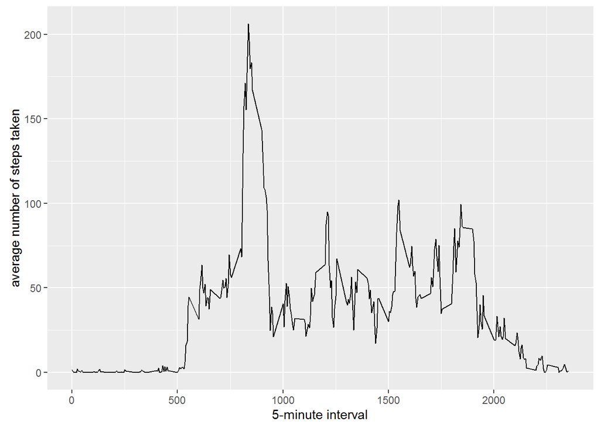

```r
ggplot(interval, aes(x=interval, y=steps)) + geom_line(color = "black")+ xlab("5-minute interval") +
    ylab("average number of steps taken")
```

###What time of day is the most active?

```r
interval[which.max(interval$steps), ]
```

```
##     interval    steps
## 104      835 206.1698
```

```r
835/60
```

```
## [1] 13.91667
```

## Missing Values

There are several data points that have NA as their step value. This may skew the data or introduce us to some intresting patterens, such as, when does the person typically remove their monitor. The original dataset, activity still has these missing values.

### Create a datafram with missing values replaced with the mean of the steps

```r
missing = transform(activity, steps = ifelse(is.na(activity$steps), mean(activity$steps, na.rm=TRUE), activity$steps))
```

### Create a new dataframe calculating the steps per day so we can have a comparison

```r
attach(missing)
stepsperday_missing <- aggregate( steps ~ date, FUN=sum)
```

### Histogram of the results

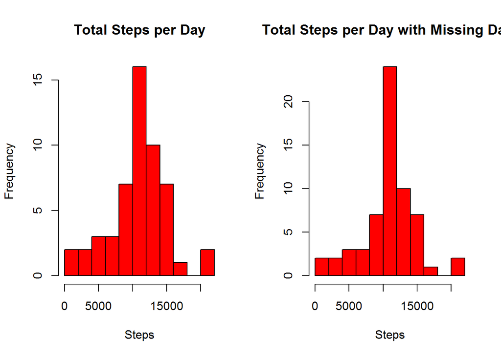

```r
par(mfrow=c(1,2))
hist(stepsperday$steps,10, col="red", main = "Total Steps per Day", xlab = "Steps", ylab = "Frequency")
hist(stepsperday_missing$steps,10, col="red", main = "Total Steps per Day with Missing Data", xlab = "Steps", ylab = "Frequency")
```

```r
mean(stepsperday$steps)
```

```
## [1] 10766.19
```

```r
median(stepsperday$steps)
```

```
## [1] 10765
```

## The Average Daily Activity Pattern

I used the dataset that included the missing values that were replaced with the mean value. I created a function that looked at the data in the date column.

```r
str(missing)
```

```
## 'data.frame':    17568 obs. of  3 variables:
##  $ steps   : num  37.4 37.4 37.4 37.4 37.4 ...
##  $ date    : chr  "2012-10-01" "2012-10-01" "2012-10-01" "2012-10-01" ...
##  $ interval: num  0 5 10 15 20 25 30 35 40 45 ...
```

```r
weekday.or.weekend <- function(date) {
  day <- weekdays(date)
  if (day %in% c("Monday", "Tuesday", "Wednesday", "Thursday", "Friday"))
    return("weekday") else if (day %in% c("Saturday", "Sunday"))
      return("weekend") else stop("invalid date")
}
missing$date <- as.Date(missing$date)
missing$day <- sapply(missing$date, FUN = weekday.or.weekend)


weeknames_averages <- aggregate(steps ~ interval + day, data = missing, mean)
```

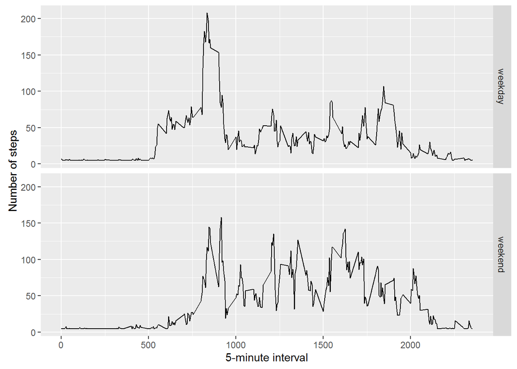

```r
ggplot(weeknames_averages, aes(interval, steps)) + geom_line() + facet_grid(day ~ .) +
  xlab("5-minute interval") + ylab("Number of steps")
```